# 基于深圳、温州两市的新冠疫情政策防控效果分析

2020/6/5

## 展示内容

- 引言
- 描述性统计
- 合成控制法
- 疫情增长率
- 总结及讨论

## 1、引言

## 研究背景及意义

- 2019年12月，湖北省武汉市爆发了新冠肺炎疫情，并逐步扩散至全国。2020年1月20日，国家卫生健康委员会宣布将其纳入乙类传染病，并采取甲类传染病的预防、控制措施。
- 在疫情尚未引起全国警觉时，恰逢与春节返乡重合之际，武汉封城后的5天时间里，依然有1.88万湖北人士进入温州，温州一度成为孤悬鄂外的最严重地区，防控压力巨大。在不到一个月的时间里，当地政府通过采取强制隔离密切接触者、对小区进行封闭式管理等紧急公共卫生措施，有效控制了疫情。
- 2020年1月23日，广东省启动重大突发公共卫生事件一级响应，而深圳市收治新冠肺炎确诊病例已达到15人。面对春节期间大型聚集活动和春运潮的压力，深圳市同日也采取了加强交通卫生检疫、停止人群聚集性活动等防控措施，不到一个月的时间里实现新增病例零增长。
- 然而，当前境外疫情仍非常严重，我国输入病例的风险仍较高。因此，总结两市阶段性的疫情特征，量化评估阶段性防控措施的效果，借鉴两市优秀的防控经验，可为其他地区以及未来突发公共卫生事件的科学防控提供参考。

## 参考文献

### **在疫情传播率计算方面**

- 流行病学通常采用基本传染数\(R_0\)来描述疾病的传播率。综合早期使用SIR、SEIR等模型的文献，COVID-19的基本传染数所属区间约为[2.0, 7.0]。由于\(R_0\)依赖于许多参数；专家们多根据自身经验进行估计；且该参数不能很好地评估流行病的**动态传播模式**。
- Maier和Brockmann发现，政策实施前后疫情增长模型中指数增长率是**动态变化**的。
- Kuchars-ki等采用一个随机传播模式估计出，政策实施一周后，疫情日传播数降到了管控实施一周前的一半以下。
- 黄锷，乔方利基于自然增长率提出了一种只包含一个参数（疫情增长率）的疫情动态传播模型，该参数随着疫情的发展而动态变化，从而能够刻画疫情发展过程中动力特征的改变。

## 参考文献

### **在防控效果量化估计方面**

- 王学钦团队使用合成控制法拟合一个“虚拟”温州，发现温州在政策实施2-3天后效果明显，如果不实施政策，温州市在2月25日每十万人将增加5人确诊。
- 王刚使用疫情动态传播模型定量评估中国政府的管控措施效果，发现从2020年1月24日 ~ 2月18日, 全国施行的严格防控政策使得1692万 ~ 7605万人免于遭受新型冠状病毒的感染。
- 综上，本文将会总结温州及深圳两市的疫情特征，使用合成控制法以及疫情动态传播模型分析温州及深圳两市防控效果，并通过政策推迟的逐日累计效应对防控效果进行量化评估。

## 参考文献

- [1]Maier B F, Brockmann D. Effective containment explains sub-exponential growth in confirmed cases of recent COVID-19 outbreak in Mainland China. 2020, arXiv: 2002.07572v1.
- [2]Kucharski A J, Russell T W, et al. Early dynamics of transmission and control of COVID-19: A mathematical modelling study. medRxiv, 2020, doi: 10.1101/2020.01.31.20019901
- [3]黄锷,乔方利.一种数据驱动的动态新型流行病传播率的提出及其在2019-nCoV疫情中的应用（英文）[J].Science Bulletin,2020,65(06): 425-427.
- [4]王刚,黄锷,乔方利.疫情管控效果的一种定量化评估方法:以COVID-19为例[J].科学通报,2020,65(11):1009-1015.

## 参考文献(续)

- [5]王学钦,史家睿,等.从病例数据对比分析影响温州与深圳疫情的特征[R],2020.03.15
- [6]刘友金,曾小明.房产税对产业转移的影响:来自重庆和上海的经验证据[J].中国工业经济,2018(11):98-116.
- [7]Alberto abadie, Alexis Diamond, and Jens Hainmueller. Synthetic Control Methods for Comparative Case Studies: Estimating the Effect of California’s Tobacco Control Program
- [8]连玉君.合成控制法 (Synthetic Control Method) 及 Stata实现.

## 数据来源

| 变量位置 | 变量名称 | 数据来源 |
| --- | --- | --- |
| 合成控制法部分 | 累计确诊人数 地区生产总值 人口密度 地区常住人口 | 各省市卫生健康委员会 省级统计年鉴（2019） |
| 描述性统计部分 疫情增长率部分 | 累计确诊人数 治愈人数 死亡人数 | [深圳市政府数据开放平台](https://opendata.sz.gov.cn/data/search/toSearch) [温州市卫生健康委员会](http://wjw.wenzhou.gov.cn/) [武汉市卫生健康委员会](http://wjw.wuhan.gov.cn/) [国家卫生健康委员会](http://www.nhc.gov.cn/) |
| 全文 | 政策措施 | 各省、市卫健委及新闻播报 |

## 2、描述性统计

## 两市疫情趋势

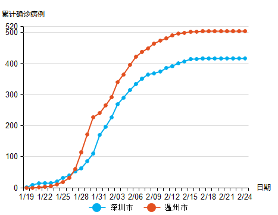

- 深圳和温州的疫情在初期比较相似，两市的累计确诊病例数在除湖北省以外的全国城市中排在前列。

## 两市疫情特征

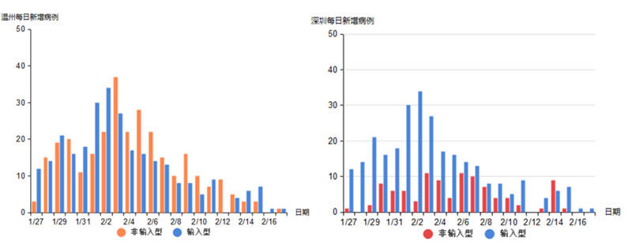

- 整体来说，温州市的疫情比深圳市的疫情严重，其主要原因是防疫政策差异和人口结构差异。

## 两市政策措施

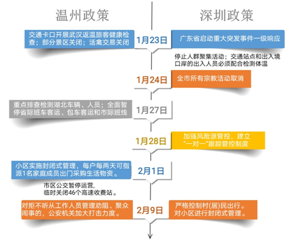

- 深圳市政策实施点：1月23号
- 温州市政策实施点：2月1号

## 3、合成控制法

## 防疫政策效果评价：以温州、深圳为例

- 疫情显露初期，各地区积极出台防控新冠肺炎政策，如何评价防疫政策效果？
- 合成控制法是评价政策效果的一种“诚实、透明”的方法。本章以温州市和深圳市两地区为例，探究其防疫政策效果。
- 此外，基于此方法，本章继续探讨并量化了两地区政策推迟实施所造成的后果。

## 合成控制法步骤

1、筛选合适的控制组，确定合理的预测变量；

2、拟合一个适宜的反事实合成组；

3、对比合成组与处理组的差异以评估政策冲击的影响；

4、安慰剂检验

## 控制组和变量选择

### 控制组选择思路

- 选定初始控制组为除自治区、特别行政区、台湾之外的268个地区，但是这些城市与温州、深圳的相似程度差别有大有小，且预测变量和结果变量数据的搜集和分析难度较大。
- 故在实施合成控制法之前需要根据各城市的地区生产总值、人口密度、以及累计确诊病例数三个变量通过K-means聚类筛选出与政策实施地区相似度较高的城市。

### 聚类结果分析

- 根据SSE准则将地区聚为四类，每个类中的个案数目结果如下：

| 类别 | 数目 |
| --- | --- |
| 1 | 160 |
| 2 | 18 |
| 3 | 29 |
| 4 | 61 |
| 有效 | 268 |
| 缺失 | 0 |

- 温州被聚到了第3类，这一类有29个地区。我们选取除温州外的28个地区作为合成控制法的控制组，分别是：  
  沈阳、抚顺、南京、无锡、徐州、苏州、宿迁、杭州、宁波、舟山、丽水、天门、黄山、三亚、三明、南昌、上饶、济南、东营、三门峡、汕尾、宜昌、荆门、荆州、新余、汕头、商丘、揭阳。
- 深圳被聚到了第2类，这一类有18个地区。我们选取除深圳外的17个地区作为合成控制法的控制组，分别是：  
  北京、天津、重庆、上海、广州、合肥、蚌埠、九江、宜春、襄阳、黄冈、咸宁、信阳、岳阳、珠海、青岛、济南。

### 主要变量

- 结果变量：发病率（每十万人确诊率）
- 预测变量：lnGDP
- 预测变量：ln人口密度
- 预测变量：累计确诊人数

### 温州SCM的效果

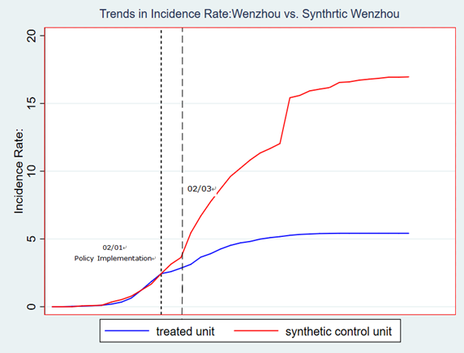

**结论：**温州的防疫政策对于发病率的降低有显著的作用。

## 深圳市SCM结果展示

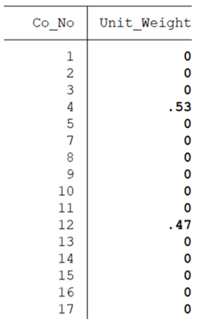

合成深圳 = 0.53×上海+0.47×黄冈

### 合成深圳与真实深圳对比

| Variable | Treated | Synthetic |
| --- | --- | --- |
| lnGDP | 10.1 | 9.087325 |
| ln人口密度 | 8.78286 | 8.496225 |
| 累计确诊人数 | 10.8 | 9.388 |
| 发病率(1/22) | 0.115145 | 0.111136 |

### 深圳市SCM的效果

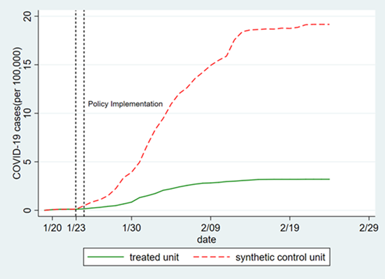

### 政策处理效应

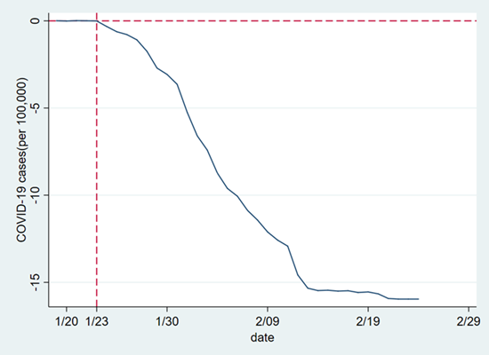

### 安慰剂检验

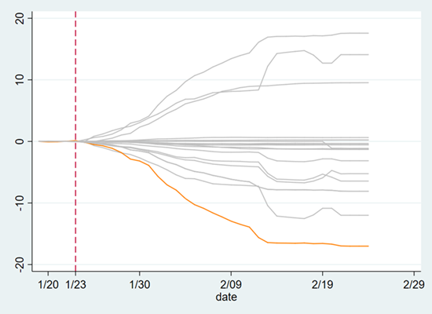

**结论：**深圳市的防疫政策对于发病率的降低有显著的作用。

## 政策推迟效应

### 思路介绍

- 政策效应的表现就是合成地区与真实地区累计确诊病例的差值。
- 以温州市为例，如推迟1天的效应：
  - 2月1日：真实数据
  - 2月2日及以后每天：真实数据+ 2月1日政策效应
- 以温州市为例，如推迟2天的效应：
  - 2月1日及2月2日：真实数据
  - 2月3日及以后每天：真实数据 + 2月1日政策效应 + 2月1日政策效应

### 温州市政策推迟效应

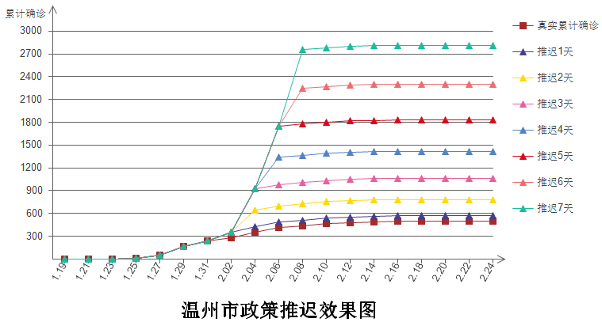

### 深圳市政策推迟效应

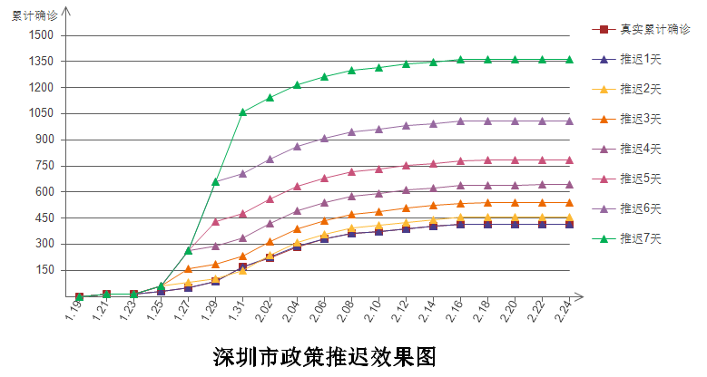

## 结论

- 温州市和深圳市的防疫政策处理效应大，防疫政策效果显著。
- 两市的防疫政策实施时间较早且合适，有效抑制了疫情的扩散。
- 防疫政策越严格，实施时间越早，对遏制疫情越有益。

## 4、疫情增长率

## 主要内容

- 模型选择的原因
- 模型的原理
- 疫情传播率对比
- 政策效果评估
- 政策推迟的逐日累积效应

## 模型选择的原因

- 疫情COVID-19的传染力较强。流行病学通常采用基本传染数\(R_0\)来描述疾病的传播率，但是\(R_0\)依赖于许多参数，这严重限制了它的实用性。
- 此外，采用一个常数来描述一个流行病发展的全过程是有些问题的。因为在事件的不同阶段，流行病的动态可能表现出不同的传播模式。
- 而且，在各种医疗和政策的干预下，流行病的进程可能会发生动态变化。
- 疫情增长率可以有效的解决上述问题，因此我们选取疫情增长率这一指标建立疫情发展动态模型对政策效应进行评估。

## 模型的原理

建立如下疫情发展动态模型：\[N(t_{k+1})=N(t_k)*e^{a(t_{k+1})*(t_{k+1}-t_k)}, k=0,1,2,……， （1）\] - \(t_k\):采样时间点。\(a(t_k)\)：随时间变化的疫情增长率。  
- \(N(t_k)\):与\(t_k\)时刻对应的现存感染者数量。  
- 现存感染者数量=确诊病例数-治愈病例数-死亡病例数  
疫情增长率的表达式:\[a(t_{k+1})=ln(N(t_{k+1})/N(t_k))/(t_{k+1}-t_k)), k=0,1,2,……， （2） \] 疫情传播率定义为:\[c(t_k)=1+a(t_k), k=0,1,2,……， （3） \] \(c(t_k)\)>1，疫情蔓延，现存感染者数量持续增加。 \(c(t_k)\)≤1，现存感染者总量达到峰值, 即疫情拐点出现。

## 疫情动态传播率对比

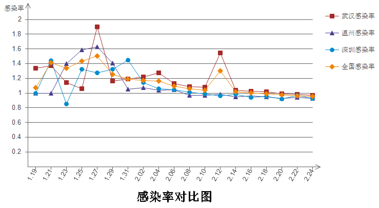

## 政策效果的评估

- 深圳于1月23日、1月24日、2月9日采取了发布通告、暂停交通等政策措施。

[output not shown]

- 温州于1月23日、1月27日、1月28日、2月1日、2月9日采取了体温检测、封闭管理等政策措施。

| 地区 | 时间段 | 初值 | 终值 | 平均增长率 |
| --- | --- | --- | --- | --- |
| 温州 | 1/21-1/23 | 2 | 6 | 0.55 |
| 温州 | 1/21-1/27 | 2 | 60 | 0.57 |
| 温州 | 1/21-1/28 | 2 | 114 | 0.58 |
| 温州 | 1/21-2/01 | 2 | 265 | 0.44 |
| 温州 | 1/21-2/09 | 2 | 464 | 0.28 |
| 温州 | 1/21-2/24 | 2 | 504 | 0.13 |

## 政策推迟的逐日累积效应

- 我们采用增长率模型来做估算，分析温州和深圳两个地区的政策推迟实施对疫情带来的影响。模型分3个时间段估算：实际政策实施开始之前的时段、实际政策与假定政策实施开始之间的时段、假定政策实施开始之后的时段。
- 第一时段：现存感染者人数采用实际数据，不做任何近似处理。
- 第二时段：增长率设为常数, 用增长率计算现存感染者数量。
- 第三时段：采用从假定政策实施日期开始的实际增长率。

— 温州市的政策实施开始时间定于2月1日,深圳定于1月23日。

[output not shown]

| 地区 | 第一时段 | 第二时段 | 第三时段 |
| --- | --- | --- | --- |
| 深圳 | 1月23日之前 | 1月24日（延迟1天） | 1月24日之后 |
|  | 1月23日之前 | 1月24日-1月25日（延迟2天） | 1月25日之后 |
|  | 1月23日之前 | 1月24日-1月26日（延迟3天） | 1月26日之后 |

- 计算第二时段所用到的设为常数的增长率：

| 地区 | 时间段 | 初值 | 终值 | 平均增长率 |
| --- | --- | --- | --- | --- |
| 深圳 | 1/19-1/23 | 1 | 13 | 0.641237 |
| 温州 | 1/21-2/01 | 2 | 253 | 0.440381 |

- 温州深圳两市从政策开始施行的时间，进行1-7天的政策延迟，由疫情传播模型得到现存感染者人数。假定政策推迟1~7天开始实施, 预估现存感染者人数。
- 深圳市政策推迟效果如下：

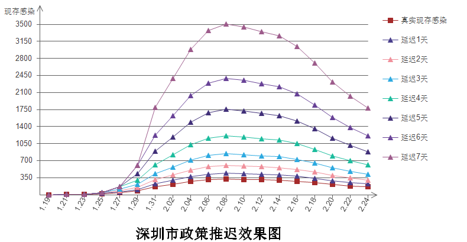

- 温州市政策推迟效果如下：

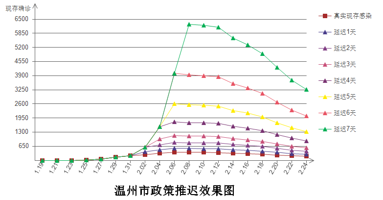

- 若深圳市的政策推迟1天实施, 截至2020年2月24日深圳现存感染者数量将比实际统计数据高出61人, 若政策推迟7天，截至2020年2月24日深圳现存感染者数量将比实际统计数据高出1621人。
- 若温州市的政策推迟1天实施, 截至2020年2月24日温州现存感染者数量将比实际统计数据高出92人, 若政策推迟7天截至2020年2月24日温州现存感染者数量将比实际统计数据高出3068人。

## 5、总结与讨论

## 总结与讨论

- 本文研究结果表明，温州及深圳两市在新型冠状病毒肺炎防控过程中采取了**有效且及时**的防控措施，并且都取得了很好的防控效果。若政策推迟实施，现存感染人数将会远超实际。
- 截止到2020年2月24日，温州市累计确诊病例504例，累计治愈出院307例，死亡1例，新增病例实现零增长。温州的确诊人数之多建立在“早发现、早隔离、早诊断、早治疗”的防疫工作原则上，高治愈率，低死亡率。2月1日施行的疫情防控“25条”紧急措施以最大限度减少了人员流动，以最大力度控制了疫情传播，是对民众生命的负责，对城市安全的负责。

## 总结与讨论

- 作为我国最大的移民城市，人口密度高、外来人口多给深圳带来巨大的疫情防控压力。深圳市政府坚持“外防输入、内控传播”的原则，通过严守进城关，不漏一车一人；通过筑牢小区关，100%围合封闭；通过扼守厂园关，筑坚固防疫盾。
- 截止到2020年2月24日，深圳市累计确诊病例417例，累计治愈出院249例，死亡3例，深圳紧紧咬住三大关口，全方位应对这次挑战，防控经验值得借鉴。
- 使用合成控制法和疫情增长率估算出来的政策推迟效应我们这里不做对比，是因为合成控制法所采用的是累计确诊人数，而疫情增长率所采用的指标是感染人数。总的来说，不同方法得到的政策延迟效应一致：随着政策实施延迟天数的增加，现存感染人数逐渐增加，累计确诊人数也逐渐增加。

将两市的成功防控经验总结如下：

- 防止外来输入病例，并通过全面排查尽早发现可能的感染者**控制传染源**。这是疫情初期防控措施的关键。
- 通过交通停运及小区封闭式管理等严厉的防控措施加强对老百姓的引导，减少人与人之间的接触，**切断传播途径**，快速高效控制疫情。
- 通过媒体宣传引导，凝聚疫情防控的社会共识，防止人为恶意传播，确保防控工作有序进行。

希望温州及深圳两市的成功防控经验能够成为未来我国及其他国家和地区处理相似公共卫生事件的参考。